# Titanic

GAN LING

2017/5/15

install the neccessary package

```r
# install.packages("caret")
# install.packages("randomForest")
# install.packages("e1071")
# install.packages("psych")
# install.packages("lattice")
# install.packages("lsr")
# install.packages("rpart")
# install.packages("ada")
# install.packages("plyr")
# install.packages("kernlab")
# install.packages("LiblineaR")
# install.packages("klaR")
```

load all the neccessary package

```r
library(ggplot2)
library(psych)
library(lsr)
library(caret)
library(randomForest)
library(lattice)
library(e1071)
library(rpart)
library(ada)
library(plyr)
library(kernlab)
library(LiblineaR)
library(klaR)
library(MASS)
```

read the data

```r
trainSet <- read.csv("train.csv")
testSet <- read.csv("test.csv")
# convert some of them to factor
trainSet$Survived <- factor(trainSet$Survived)
trainSet$Pclass <- factor(trainSet$Pclass)
```

clean the data

```r
summary(trainSet)
```

```
##   PassengerId    Survived Pclass
##  Min.   :  1.0   0:549    1:216
##  1st Qu.:223.5   1:342    2:184
##  Median :446.0            3:491
##  Mean   :446.0
##  3rd Qu.:668.5
##  Max.   :891.0
##
##                                     Name         Sex           Age
##  Abbing, Mr. Anthony                  :  1   female:314   Min.   : 0.42
##  Abbott, Mr. Rossmore Edward          :  1   male  :577   1st Qu.:20.12
##  Abbott, Mrs. Stanton (Rosa Hunt)     :  1                Median :28.00
##  Abelson, Mr. Samuel                  :  1                Mean   :29.70
##  Abelson, Mrs. Samuel (Hannah Wizosky):  1                3rd Qu.:38.00
##  Adahl, Mr. Mauritz Nils Martin       :  1                Max.   :80.00
##  (Other)                              :885                NA's   :177
##      SibSp           Parch             Ticket         Fare
##  Min.   :0.000   Min.   :0.0000   1601    :  7   Min.   :  0.00
##  1st Qu.:0.000   1st Qu.:0.0000   347082  :  7   1st Qu.:  7.91
##  Median :0.000   Median :0.0000   CA. 2343:  7   Median : 14.45
##  Mean   :0.523   Mean   :0.3816   3101295 :  6   Mean   : 32.20
##  3rd Qu.:1.000   3rd Qu.:0.0000   347088  :  6   3rd Qu.: 31.00
##  Max.   :8.000   Max.   :6.0000   CA 2144 :  6   Max.   :512.33
##                                   (Other) :852
##          Cabin     Embarked
##             :687    :  2
##  B96 B98    :  4   C:168
##  C23 C25 C27:  4   Q: 77
##  G6         :  4   S:644
##  C22 C26    :  3
##  D          :  3
##  (Other)    :186
```

```r
# From our result only Age has NA values. We get that Age has 177
# NA values, Cabin has 687 blank values, and Embarked has 2 blank values.
# We do not use Cabin, so we do not deal with it. The 2 blank
# values maybe affect our result. And most of Embarked are S
# so we define two blank values to S
trainSet$Embarked[trainSet$Embarked==""] = "S"
```

see all of the variables we use in ggplot2

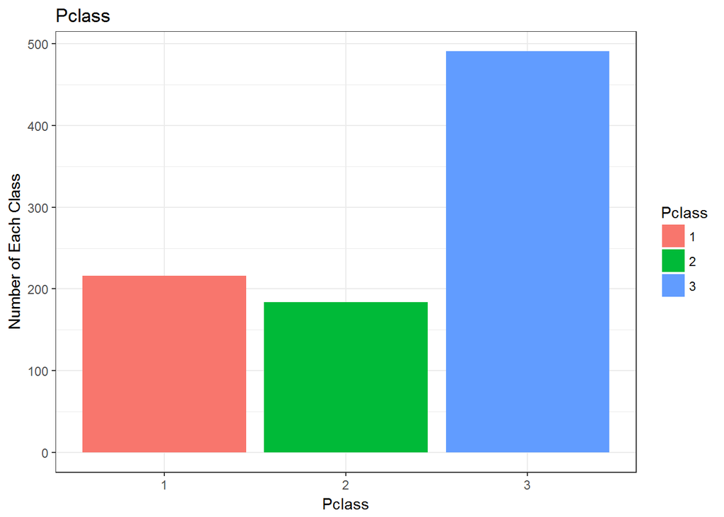

```r
# Pclass command
ggplot(trainSet, aes(x=Pclass,fill=Pclass)) +
    geom_bar() +
    xlab("Pclass") +
    ylab("Number of Each Class") +
    ggtitle("Pclass") +
    theme_bw()
```

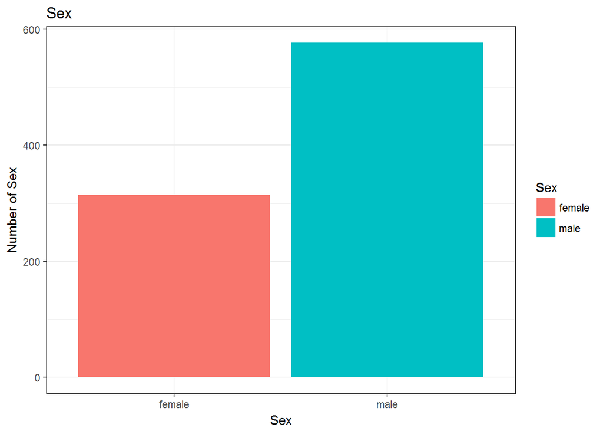

```r
# Sex command
ggplot(data=trainSet, aes(x=Sex, fill=Sex)) +
    geom_bar() +
    ggtitle("Sex") +
    labs(y="Number of Sex", x="Sex") +
    theme_bw()
```

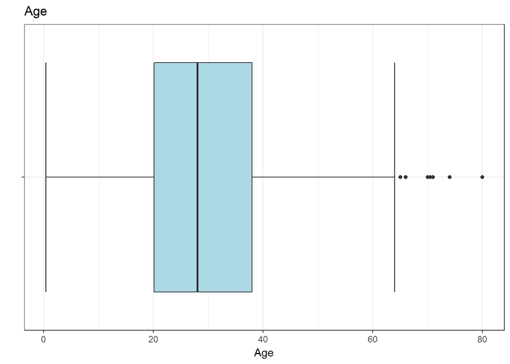

```r
# Age command
ggplot(trainSet, aes(x="", y=Age)) +
    stat_boxplot(geom ='errorbar')+
    geom_boxplot(fill="lightblue") +
    xlab("") +
    guides(fill=FALSE) +
    ggtitle("Age") +
    coord_flip() +
    theme_bw()
```

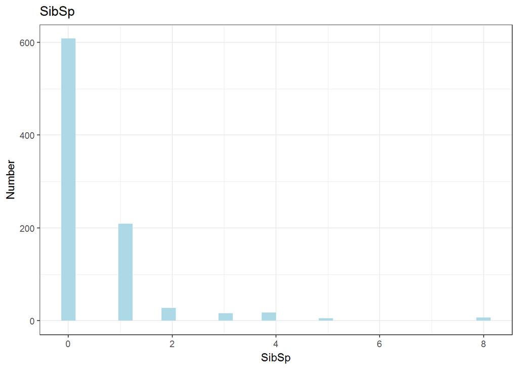

```r
# SibSp command
ggplot(trainSet, aes(x=SibSp)) +
    geom_histogram() +
    geom_histogram(fill="lightblue") +
    xlab("SibSp") +
    ylab("Number") +
    guides(fill=FALSE) +
    ggtitle("SibSp") +
    theme_bw()
```

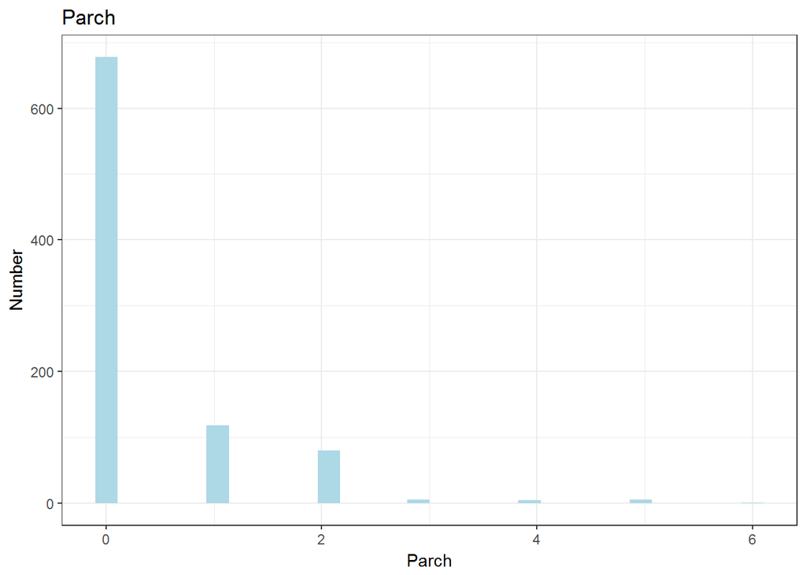

```r
# Parch command
ggplot(trainSet, aes(x=Parch)) +
    geom_histogram() +
    geom_histogram(fill="lightblue") +
    xlab("Parch") +
    ylab("Number") +
    guides(fill=FALSE) +
    ggtitle("Parch") +
    theme_bw()
```

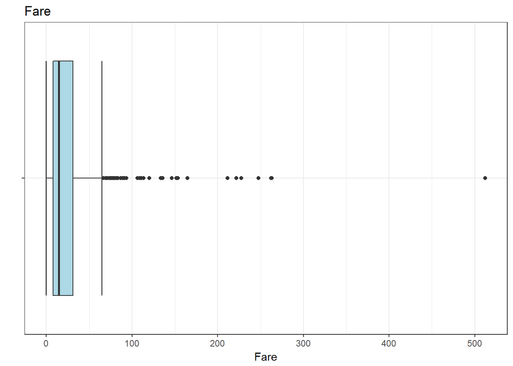

```r
# Fare command
ggplot(trainSet, aes(x="", y=Fare)) +
    stat_boxplot(geom ='errorbar')+
    geom_boxplot(fill="lightblue") +
    xlab("") +
    guides(fill=FALSE) +
    ggtitle("Fare") +
    coord_flip() +
    theme_bw()
```

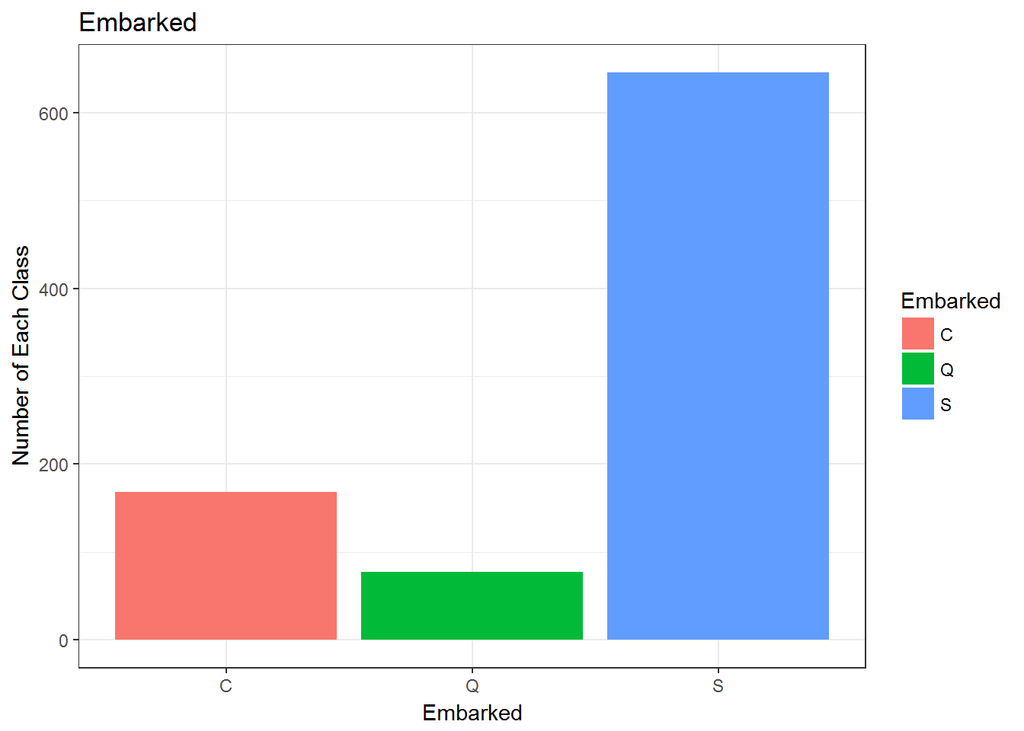

```r
# Embarked command
ggplot(trainSet, aes(x=Embarked,fill=Embarked)) +
    geom_bar() +
    xlab("Embarked") +
    ylab("Number of Each Class") +
    ggtitle("Embarked") +
    theme_bw()
```

get some statistical test to see the correlation between single variable and output

```r
# Pclass
associationTest(~ Survived + Pclass, data = trainSet)
```

```
##
##      Chi-square test of categorical association
##
## Variables:   Survived, Pclass
##
## Hypotheses:
##    null:        variables are independent of one another
##    alternative: some contingency exists between variables
##
## Observed contingency table:
##         Pclass
## Survived   1   2   3
##        0  80  97 372
##        1 136  87 119
##
## Expected contingency table under the null hypothesis:
##         Pclass
## Survived     1     2   3
##        0 133.1 113.4 303
##        1  82.9  70.6 188
##
## Test results:
##    X-squared statistic:  102.889
##    degrees of freedom:  2
##    p-value:  <.001
##
## Other information:
##    estimated effect size (Cramer's v):  0.34
```

```r
# Sex
associationTest(~ Survived + Sex, data = trainSet)
```

```
##
##      Chi-square test of categorical association
##
## Variables:   Survived, Sex
##
## Hypotheses:
##    null:        variables are independent of one another
##    alternative: some contingency exists between variables
##
## Observed contingency table:
##         Sex
## Survived female male
##        0     81  468
##        1    233  109
##
## Expected contingency table under the null hypothesis:
##         Sex
## Survived female male
##        0    193  356
##        1    121  221
##
## Test results:
##    X-squared statistic:  260.717
##    degrees of freedom:  1
##    p-value:  <.001
##
## Other information:
##    estimated effect size (Cramer's v):  0.541
##    Yates' continuity correction has been applied
```

```r
# Age
independentSamplesTTest(Age ~ Survived, data = trainSet)
```

```
##
##    Welch's independent samples t-test
##
## Outcome variable:   Age
## Grouping variable:  Survived
##
## Descriptive statistics:
##                  0      1
##    mean     30.626 28.344
##    std dev. 14.172 14.951
##
## Hypotheses:
##    null:        population means equal for both groups
##    alternative: different population means in each group
##
## Test results:
##    t-statistic:  2.046
##    degrees of freedom:  598.841
##    p-value:  0.041
##
## Other information:
##    two-sided 95% confidence interval:  [0.092, 4.473]
##    estimated effect size (Cohen's d):  0.157
```

```r
# SibSp
independentSamplesTTest(SibSp ~ Survived, data = trainSet)
```

```
##
##    Welch's independent samples t-test
##
## Outcome variable:   SibSp
## Grouping variable:  Survived
##
## Descriptive statistics:
##                 0     1
##    mean     0.554 0.474
##    std dev. 1.288 0.709
##
## Hypotheses:
##    null:        population means equal for both groups
##    alternative: different population means in each group
##
## Test results:
##    t-statistic:  1.194
##    degrees of freedom:  877.088
##    p-value:  0.233
##
## Other information:
##    two-sided 95% confidence interval:  [-0.051, 0.212]
##    estimated effect size (Cohen's d):  0.077
```

```r
# Parch
independentSamplesTTest(Parch ~ Survived, data = trainSet)
```

```
##
##    Welch's independent samples t-test
##
## Outcome variable:   Parch
## Grouping variable:  Survived
##
## Descriptive statistics:
##                 0     1
##    mean     0.330 0.465
##    std dev. 0.823 0.772
##
## Hypotheses:
##    null:        population means equal for both groups
##    alternative: different population means in each group
##
## Test results:
##    t-statistic:  -2.479
##    degrees of freedom:  758.568
##    p-value:  0.013
##
## Other information:
##    two-sided 95% confidence interval:  [-0.242, -0.028]
##    estimated effect size (Cohen's d):  0.169
```

```r
# Fare
independentSamplesTTest(Fare ~ Survived, data = trainSet)
```

```
##
##    Welch's independent samples t-test
##
## Outcome variable:   Fare
## Grouping variable:  Survived
##
## Descriptive statistics:
##                  0      1
##    mean     22.118 48.395
##    std dev. 31.388 66.597
##
## Hypotheses:
##    null:        population means equal for both groups
##    alternative: different population means in each group
##
## Test results:
##    t-statistic:  -6.839
##    degrees of freedom:  436.702
##    p-value:  <.001
##
## Other information:
##    two-sided 95% confidence interval:  [-33.829, -18.726]
##    estimated effect size (Cohen's d):  0.505
```

```r
# Embarked
associationTest(~ Survived + Embarked, data = trainSet)
```

```
##
##      Chi-square test of categorical association
##
## Variables:   Survived, Embarked
##
## Hypotheses:
##    null:        variables are independent of one another
##    alternative: some contingency exists between variables
##
## Observed contingency table:
##         Embarked
## Survived       C   Q   S
##        0   0  75  47 427
##        1   0  93  30 219
##
## Expected contingency table under the null hypothesis:
##         Embarked
## Survived       C    Q   S
##        0 0 103.5 47.4 398
##        1 0  64.5 29.6 248
##
## Test results:
##    X-squared statistic:  NaN
##    degrees of freedom:  3
##    p-value:  NA
##
## Other information:
##    estimated effect size (Cramer's v):  NaN
```

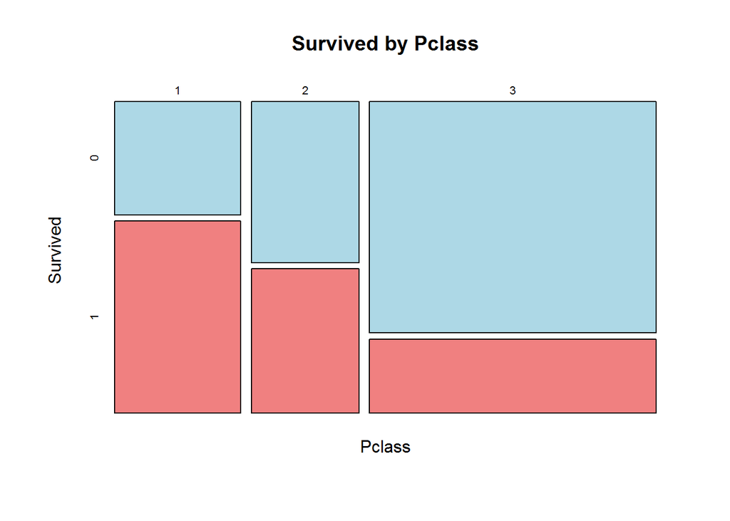

```r
#draw them
# Pclass command
mosaicplot(table(trainSet$Pclass,trainSet$Survived),
           ylab="Survived",xlab="Pclass",
           color=c("lightblue","lightcoral"),
           main="Survived by Pclass")
```

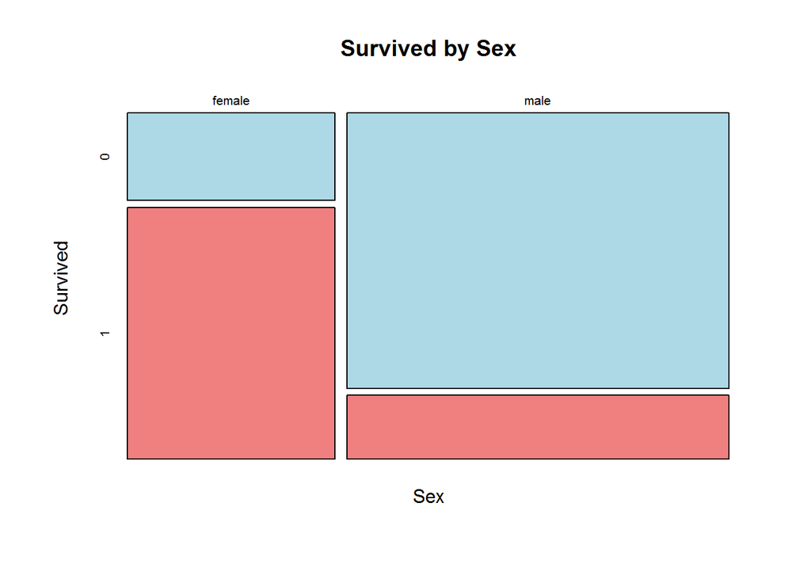

```r
# Sex command
mosaicplot(table(trainSet$Sex,trainSet$Survived),
           ylab="Survived",xlab="Sex",
           color=c("lightblue","lightcoral"),
           main="Survived by Sex")
```

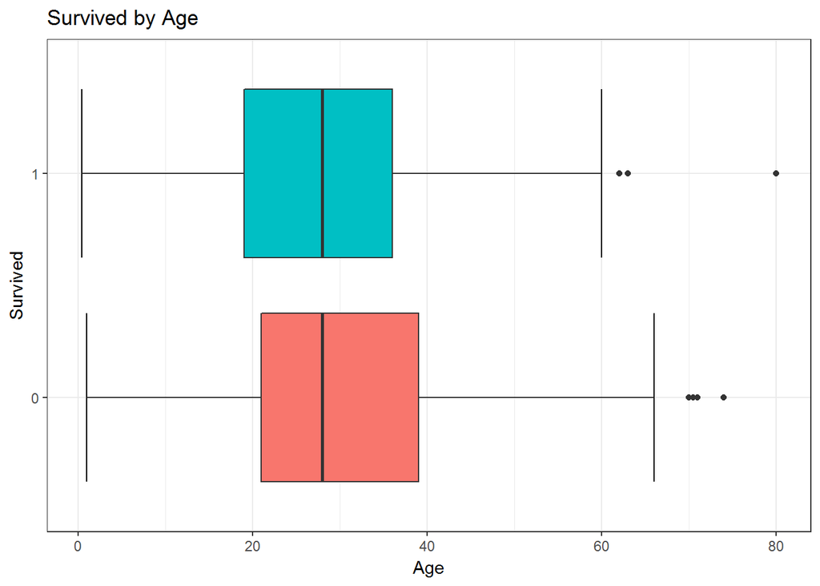

```r
# Age command
ggplot(trainSet, aes(x=Survived, y=Age, fill=Survived)) +
    stat_boxplot(geom ='errorbar') +
    geom_boxplot() +
    guides(fill=FALSE) +
    coord_flip() +
    ggtitle("Survived by Age") +
    theme_bw()
```

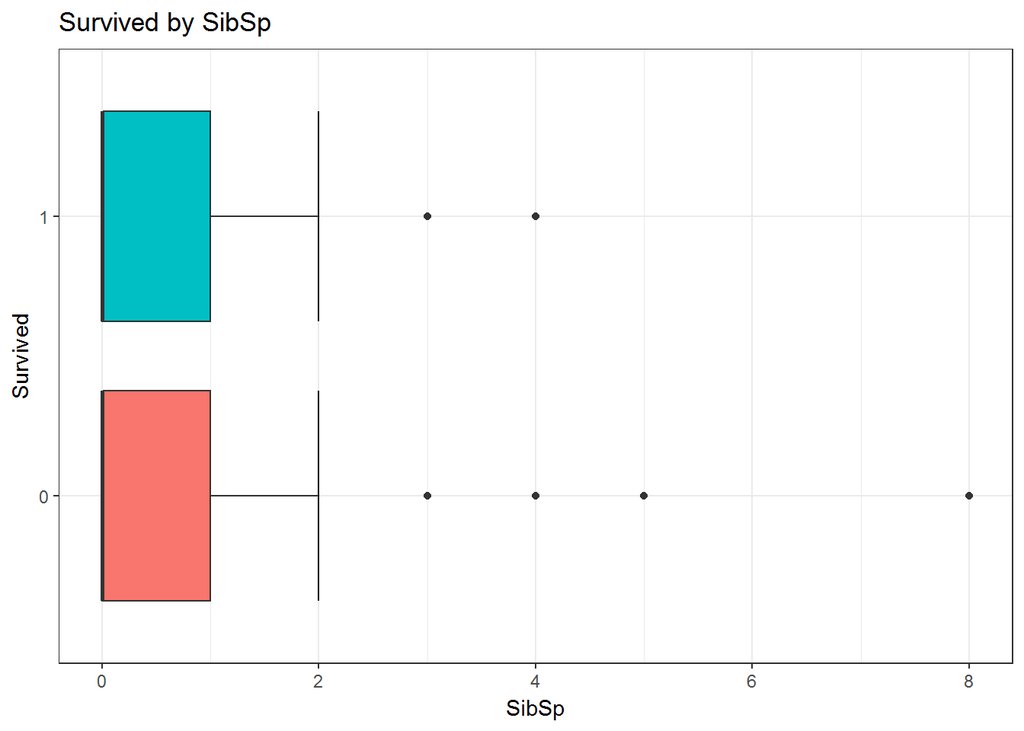

```r
# SibSp command
ggplot(trainSet, aes(x=Survived, y=SibSp, fill=Survived)) +
    stat_boxplot(geom ='errorbar') +
    geom_boxplot() +
    guides(fill=FALSE) +
    coord_flip() +
    ggtitle("Survived by SibSp") +
    theme_bw()
```

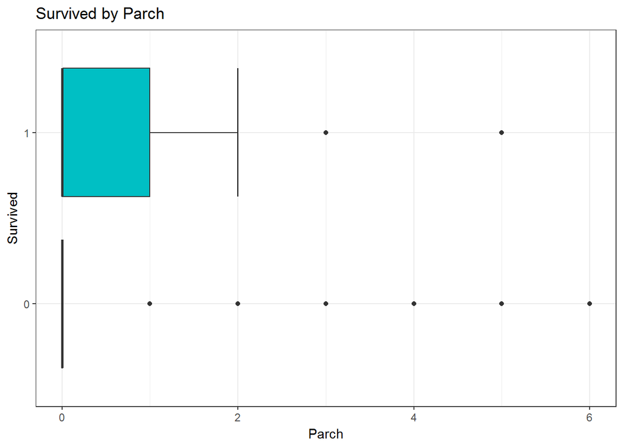

```r
# Parch command
ggplot(trainSet, aes(x=Survived, y=Parch, fill=Survived)) +
    stat_boxplot(geom ='errorbar') +
    geom_boxplot() +
    guides(fill=FALSE) +
    coord_flip() +
    ggtitle("Survived by Parch") +
    theme_bw()
```

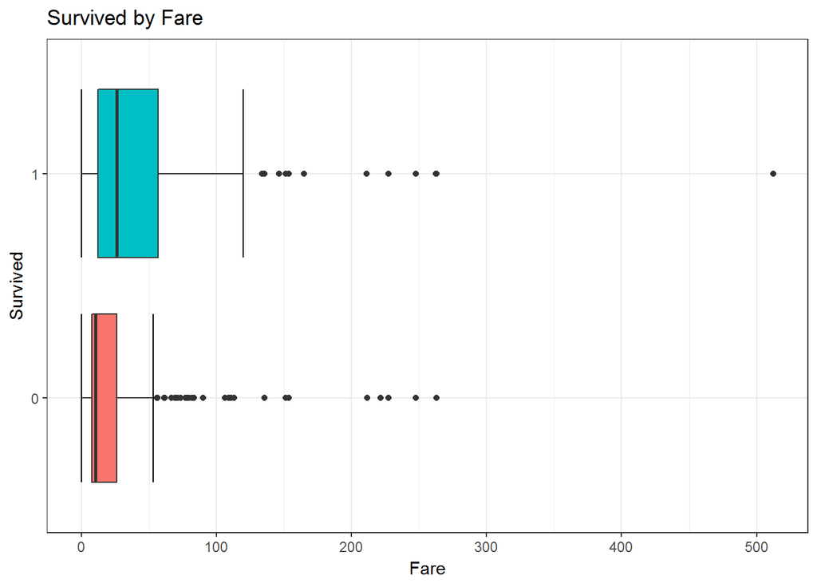

```r
# Fare command
ggplot(trainSet, aes(x=Survived, y=Fare, fill=Survived)) +
    stat_boxplot(geom ='errorbar') +
    geom_boxplot() +
    guides(fill=FALSE) +
    coord_flip() +
    ggtitle("Survived by Fare") +
    theme_bw()
```

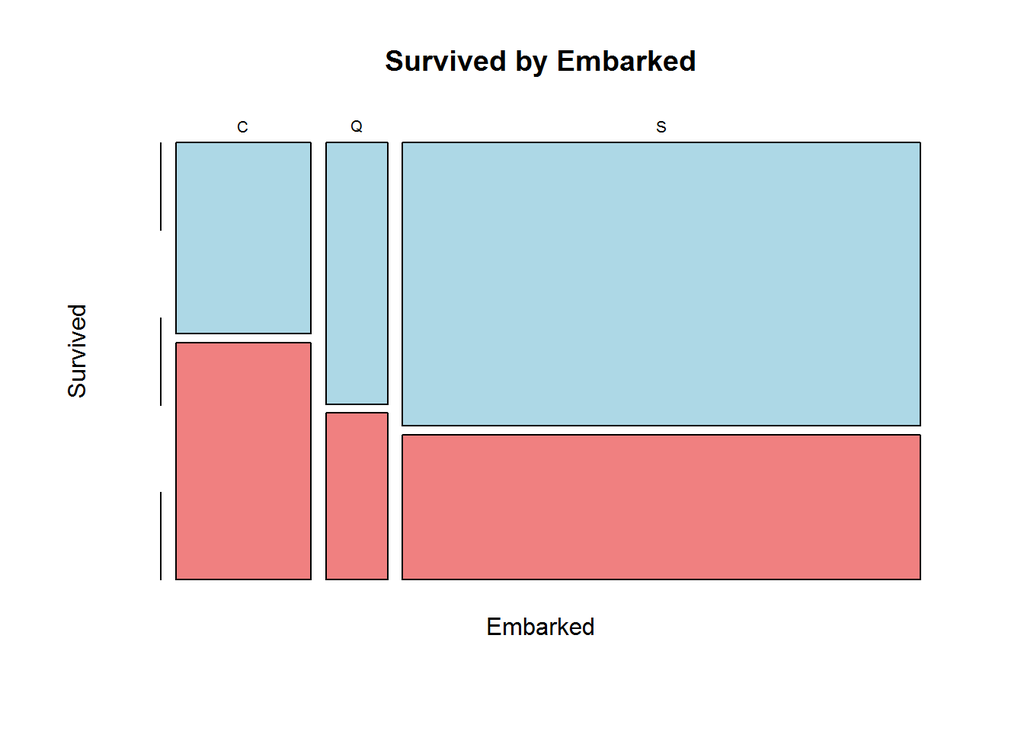

```r
# Embarked command
mosaicplot(table(trainSet$Embarked,trainSet$Survived),
           ylab="Survived",xlab="Embarked",
           color=c("lightblue","lightcoral"),
           main="Survived by Embarked")
```

use glm model to do the train

```r
summary(glm(Survived ~ Pclass+Age+Sex+SibSp+Parch+Fare+Embarked,
            data = trainSet, family = "binomial"))
```

```
##
## Call:
## glm(formula = Survived ~ Pclass + Age + Sex + SibSp + Parch +
##     Fare + Embarked, family = "binomial", data = trainSet)
##
## Deviance Residuals:
##     Min       1Q   Median       3Q      Max
## -2.7261  -0.6439  -0.3756   0.6317   2.4453
##
## Coefficients:
##              Estimate Std. Error z value Pr(>|z|)
## (Intercept)  4.437927   0.536139   8.278  < 2e-16 ***
## Pclass2     -1.199103   0.329081  -3.644 0.000269 ***
## Pclass3     -2.403080   0.343396  -6.998 2.60e-12 ***
## Age         -0.043131   0.008311  -5.190 2.11e-07 ***
## Sexmale     -2.648341   0.222682 -11.893  < 2e-16 ***
## SibSp       -0.364668   0.129459  -2.817 0.004850 **
## Parch       -0.062502   0.123969  -0.504 0.614140
## Fare         0.001484   0.002602   0.570 0.568407
## EmbarkedQ   -0.821842   0.600874  -1.368 0.171392
## EmbarkedS   -0.395724   0.274553  -1.441 0.149488
## ---
## Signif. codes:  0 '***' 0.001 '**' 0.01 '*' 0.05 '.' 0.1 ' ' 1
##
## (Dispersion parameter for binomial family taken to be 1)
##
##     Null deviance: 964.52  on 713  degrees of freedom
## Residual deviance: 632.91  on 704  degrees of freedom
##   (177 observations deleted due to missingness)
## AIC: 652.91
##
## Number of Fisher Scoring iterations: 5
```

do a backward step test for the training set using glm

```r
step(object=glm(Survived ~ Pclass+Age+Sex+SibSp+Parch+Fare+Embarked,
                data = trainSet, family = "binomial"),
                direction = "backward")
```

```
## Start:  AIC=652.91
## Survived ~ Pclass + Age + Sex + SibSp + Parch + Fare + Embarked
##
##            Df Deviance    AIC
## - Parch     1   633.17 651.17
## - Fare      1   633.25 651.25
## - Embarked  2   635.78 651.78
## <none>          632.91 652.91
## - SibSp     1   641.48 659.48
## - Age       1   662.53 680.53
## - Pclass    2   687.34 703.34
## - Sex       1   809.65 827.65
##
## Step:  AIC=651.17
## Survived ~ Pclass + Age + Sex + SibSp + Fare + Embarked
##
##            Df Deviance    AIC
## - Fare      1   633.40 649.40
## - Embarked  2   636.03 650.03
## <none>          633.17 651.17
## - SibSp     1   643.36 659.36
## - Age       1   662.77 678.77
## - Pclass    2   690.79 704.79
## - Sex       1   814.47 830.47
##
## Step:  AIC=649.4
## Survived ~ Pclass + Age + Sex + SibSp + Embarked
##
##            Df Deviance    AIC
## - Embarked  2   636.56 648.56
## <none>          633.40 649.40
## - SibSp     1   643.36 657.36
## - Age       1   663.75 677.75
## - Pclass    2   720.58 732.58
## - Sex       1   818.01 832.01
##
## Step:  AIC=648.56
## Survived ~ Pclass + Age + Sex + SibSp
##
##          Df Deviance    AIC
## <none>        636.56 648.56
## - SibSp   1   647.28 657.28
## - Age     1   669.40 679.40
## - Pclass  2   742.29 750.29
## - Sex     1   823.72 833.72
```

```
##
## Call:  glm(formula = Survived ~ Pclass + Age + Sex + SibSp, family = "binomial",
##     data = trainSet)
##
## Coefficients:
## (Intercept)      Pclass2      Pclass3          Age      Sexmale
##     4.33420     -1.41436     -2.65262     -0.04476     -2.62768
##       SibSp
##    -0.38019
##
## Degrees of Freedom: 713 Total (i.e. Null);  708 Residual
##   (177 observations deleted due to missingness)
## Null Deviance:       964.5
## Residual Deviance: 636.6     AIC: 648.6
```

because there is so many extreme data in Fare, we can use log to normalize the data

```r
trainSet$logFare<-log(trainSet$Fare)
```

use new data to do the training

we dealed with Fare using log, and there are some Fare values equal to 0, log(0) is -Inf, we need to ignore all the -Inf before training

```r
step(object=glm(Survived ~ Pclass+Age+Sex+SibSp+Parch+logFare+Embarked,
                data = trainSet[!is.infinite(trainSet$logFare),],
                family = "binomial"), direction = "backward")
```

```
## Start:  AIC=644.56
## Survived ~ Pclass + Age + Sex + SibSp + Parch + logFare + Embarked
##
##            Df Deviance    AIC
## - logFare   1   624.61 642.61
## - Parch     1   624.76 642.76
## - Embarked  2   627.14 643.14
## <none>          624.56 644.56
## - SibSp     1   632.01 650.01
## - Pclass    2   652.95 668.95
## - Age       1   654.86 672.86
## - Sex       1   798.73 816.73
##
## Step:  AIC=642.61
## Survived ~ Pclass + Age + Sex + SibSp + Parch + Embarked
##
##            Df Deviance    AIC
## - Parch     1   624.76 640.76
## - Embarked  2   627.41 641.41
## <none>          624.61 642.61
## - SibSp     1   633.09 649.09
## - Age       1   655.28 671.28
## - Pclass    2   714.63 728.63
## - Sex       1   801.27 817.27
##
## Step:  AIC=640.76
## Survived ~ Pclass + Age + Sex + SibSp + Embarked
##
##            Df Deviance    AIC
## - Embarked  2   627.52 639.52
## <none>          624.76 640.76
## - SibSp     1   634.91 648.91
## - Age       1   655.34 669.34
## - Pclass    2   714.97 726.97
## - Sex       1   807.76 821.76
##
## Step:  AIC=639.52
## Survived ~ Pclass + Age + Sex + SibSp
##
##          Df Deviance    AIC
## <none>        627.52 639.52
## - SibSp   1   638.42 648.42
## - Age     1   660.51 670.51
## - Pclass  2   736.51 744.51
## - Sex     1   812.68 822.68
```

```
##
## Call:  glm(formula = Survived ~ Pclass + Age + Sex + SibSp, family = "binomial",
##     data = trainSet[!is.infinite(trainSet$logFare), ])
##
## Coefficients:
## (Intercept)      Pclass2      Pclass3          Age      Sexmale
##     4.40124     -1.47056     -2.72404     -0.04502     -2.62990
##       SibSp
##    -0.38491
##
## Degrees of Freedom: 706 Total (i.e. Null);  701 Residual
##   (169 observations deleted due to missingness)
## Null Deviance:       956.4
## Residual Deviance: 627.5     AIC: 639.5
```

about the age, we use a random number between maximum and minimum as NA’s age.

```r
set.seed(as.numeric(as.Date("2017-05-15")))
trainSet$totalAge <- ifelse(is.na(trainSet$Age),
                            as.integer(runif(177,min=0.42,max=80)),
                            trainSet$Age)
```

train the data using Random Forest model

```r
set.seed(as.numeric(as.Date("2017-05-15")))
model <- train(Survived ~ Pclass + totalAge + Sex + SibSp + Embarked,
               data = trainSet,
               # Use the trainSet dataframe as the training data
               method = "rf",
               # Use the "random forest" algorithm
               trControl = trainControl(method = "cv",
                                        # Use cross-validation
                                        number = 10)
                                # Use 10 folds for cross-validation
)
model
```

```
## Random Forest
##
## 891 samples
##   5 predictor
##   2 classes: '0', '1'
##
## No pre-processing
## Resampling: Cross-Validated (10 fold)
## Summary of sample sizes: 802, 802, 802, 803, 801, 802, ...
## Resampling results across tuning parameters:
##
##   mtry  Accuracy   Kappa
##   2     0.8193599  0.5941928
##   5     0.8215438  0.6102005
##   8     0.7868117  0.5467209
##
## Accuracy was used to select the optimal model using  the largest value.
## The final value used for the model was mtry = 5.
```

```r
# the accuracy rate is 0.8215438
```

now we can draw the graph

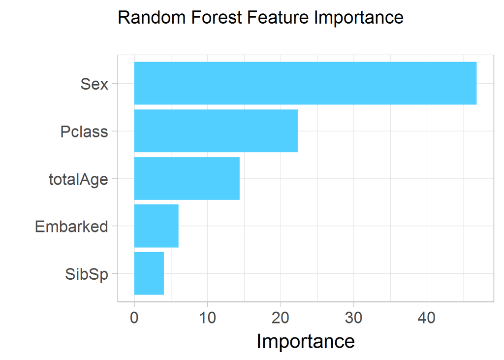

```r
extractFeatures <- function(data) {
    features <- c("Pclass",
                  "totalAge",
                  "Sex",
                  "SibSp",
                  "Embarked")
    fea <- data[,features]
    # fea$Embarked[fea$Embarked==""] = "S"
    fea$Sex      <- as.factor(fea$Sex)
    fea$Embarked <- as.factor(fea$Embarked)
    return(fea)
}
rf <- randomForest(extractFeatures(trainSet), as.factor(trainSet$Survived), ntree=100, importance=TRUE)
imp <- importance(rf, type=1)
featureImportance <- data.frame(Feature=row.names(imp), Importance=imp[,1])

ggplot(featureImportance, aes(x=reorder(Feature, Importance), y=Importance)) +
    geom_bar(stat="identity", fill="#53cfff") +
    coord_flip() +
    theme_light(base_size=20) +
    xlab("") +
    ylab("Importance") +
    ggtitle("Random Forest Feature Importance\n") +
    theme(plot.title=element_text(size=18))
```

### *The accuracy using random forest is `0.8215438`*

establish the output for testset

```r
testSet$Pclass <- factor(testSet$Pclass)
testSet$totalAge <- ifelse(is.na(testSet$Age),
                       mean(testSet$Age, na.rm = TRUE),
                       testSet$Age)
testSet$Survived <- predict(model, newdata = testSet)
submission <- testSet[,c("PassengerId", "Survived")]
write.table(submission, file = "submission.csv",
            col.names = TRUE, row.names = FALSE, sep = ",")
```

### Now we can change the algorithms and the combination of variables to get some new results:

```r
# first of all, because we need to use this process several
# times, we will build a function to save the repetitive work
train_the_data <- function(method_use, isUsingEmbarked) {
    # set the seed first so you can get the same result as me
    set.seed(as.numeric(as.Date("2017-05-15")))
    # method_use argument means using method in train function
    # if isUsingEmbarked argument is TRUE, the variables will be
    # Pclass + totalAge + Sex + SibSp + Embarked, otherwise will
    # be Pclass + totalAge + Sex + SibSp
    if (isUsingEmbarked == TRUE) {
        model <- train(Survived ~ Pclass + totalAge + Sex + SibSp + Embarked,
                       data = trainSet,
                       # Use the trainSet dataframe as the training data
                       method = method_use,
                       # Use the algorithm we defined
                       trControl = trainControl(method = "cv",
                                                # Use cross-validation
                                                number = 10)
                       # Use 10 folds for cross-validation
        )
    }
    else {
        model <- train(Survived ~ Pclass + totalAge + Sex + SibSp,
                       data = trainSet,
                       # Use the trainSet dataframe as the training data
                       method = method_use,
                       # Use the algorithm we defined
                       trControl = trainControl(method = "cv",
                                                # Use cross-validation
                                                number = 10)
                       # Use 10 folds for cross-validation
        )
    }
    return(model)
}
```

### Neural Network

```r
# test with Embarked
model <- train_the_data("nnet", TRUE)
model
```

```
## Neural Network
##
## 891 samples
##   5 predictor
##   2 classes: '0', '1'
##
## No pre-processing
## Resampling: Cross-Validated (10 fold)
## Summary of sample sizes: 802, 802, 802, 803, 801, 802, ...
## Resampling results across tuning parameters:
##
##   size  decay  Accuracy   Kappa
##   1     0e+00  0.7619799  0.4368972
##   1     1e-04  0.7755754  0.4821419
##   1     1e-01  0.8114059  0.5830717
##   3     0e+00  0.7934159  0.5416474
##   3     1e-04  0.7934409  0.5384025
##   3     1e-01  0.8170877  0.5973138
##   5     0e+00  0.8126055  0.5877240
##   5     1e-04  0.8069501  0.5748921
##   5     1e-01  0.8114570  0.5860857
##
## Accuracy was used to select the optimal model using  the largest value.
## The final values used for the model were size = 3 and decay = 0.1.
```

```r
# the accuracy rate is 0.8170877
# test with no Embarked
model <- train_the_data("nnet", FALSE)
model
```

```
## Neural Network
##
## 891 samples
##   4 predictor
##   2 classes: '0', '1'
##
## No pre-processing
## Resampling: Cross-Validated (10 fold)
## Summary of sample sizes: 802, 802, 802, 803, 801, 802, ...
## Resampling results across tuning parameters:
##
##   size  decay  Accuracy   Kappa
##   1     0e+00  0.7597696  0.4320391
##   1     1e-04  0.7866111  0.5139114
##   1     1e-01  0.8034900  0.5670861
##   3     0e+00  0.8114317  0.5844962
##   3     1e-04  0.8124668  0.5882083
##   3     1e-01  0.8147514  0.5931250
##   5     0e+00  0.8136914  0.5917118
##   5     1e-04  0.8047270  0.5701067
##   5     1e-01  0.8147390  0.5914211
##
## Accuracy was used to select the optimal model using  the largest value.
## The final values used for the model were size = 3 and decay = 0.1.
```

```r
# the accuracy rate is 0.8147514
```

### SVM

```r
# test with Embarked
model <- train_the_data("svmLinearWeights2", TRUE)
model
```

```
## L2 Regularized Linear Support Vector Machines with Class Weights
##
## 891 samples
##   5 predictor
##   2 classes: '0', '1'
##
## No pre-processing
## Resampling: Cross-Validated (10 fold)
## Summary of sample sizes: 802, 802, 802, 803, 801, 802, ...
## Resampling results across tuning parameters:
##
##   cost  Loss  weight  Accuracy   Kappa
##   0.25  L1    1       0.7911931  0.5501884
##   0.25  L1    2       0.7854875  0.5559150
##   0.25  L1    3       0.7496320  0.4987080
##   0.25  L2    1       0.7867365  0.5427358
##   0.25  L2    2       0.7608427  0.5017978
##   0.25  L2    3       0.7451246  0.4838097
##   0.50  L1    1       0.7889459  0.5458421
##   0.50  L1    2       0.7832528  0.5521174
##   0.50  L1    3       0.7451121  0.4901813
##   0.50  L2    1       0.7867365  0.5427358
##   0.50  L2    2       0.7586454  0.5008416
##   0.50  L2    3       0.7170472  0.4483562
##   1.00  L1    1       0.7900695  0.5485342
##   1.00  L1    2       0.7866491  0.5593589
##   1.00  L1    3       0.7451121  0.4901813
##   1.00  L2    1       0.7451382  0.4800206
##   1.00  L2    2       0.7732028  0.5303551
##   1.00  L2    3       0.7175724  0.4297070
##
## Accuracy was used to select the optimal model using  the largest value.
## The final values used for the model were cost = 0.25, Loss = L1 and
##  weight = 1.
```

```r
# the accuracy is 0.7911931
# test with no Embarked
model <- train_the_data("svmLinearWeights2", FALSE)
model
```

```
## L2 Regularized Linear Support Vector Machines with Class Weights
##
## 891 samples
##   4 predictor
##   2 classes: '0', '1'
##
## No pre-processing
## Resampling: Cross-Validated (10 fold)
## Summary of sample sizes: 802, 802, 802, 803, 801, 802, ...
## Resampling results across tuning parameters:
##
##   cost  Loss  weight  Accuracy   Kappa
##   0.25  L1    1       0.7923417  0.5513621
##   0.25  L1    2       0.7911304  0.5656586
##   0.25  L1    3       0.7507428  0.5019390
##   0.25  L2    1       0.7867365  0.5427358
##   0.25  L2    2       0.7788713  0.5294934
##   0.25  L2    3       0.7541133  0.5025856
##   0.50  L1    1       0.7923417  0.5513621
##   0.50  L1    2       0.7911304  0.5656586
##   0.50  L1    3       0.7484956  0.4978199
##   0.50  L2    1       0.7867365  0.5427358
##   0.50  L2    2       0.7429534  0.4872889
##   0.50  L2    3       0.7541133  0.5063620
##   1.00  L1    1       0.7923417  0.5513621
##   1.00  L1    2       0.7900068  0.5635727
##   1.00  L1    3       0.7484956  0.4978199
##   1.00  L2    1       0.7296442  0.4508468
##   1.00  L2    2       0.7160234  0.4442731
##   1.00  L2    3       0.7731271  0.5065699
##
## Accuracy was used to select the optimal model using  the largest value.
## The final values used for the model were cost = 0.25, Loss = L1 and
##  weight = 1.
```

```r
# the accuracy is 0.7923417
```

### Desicion Tree

```r
# test with Embarked
model <- train_the_data("rpart", TRUE)
model
```

```
## CART
##
## 891 samples
##   5 predictor
##   2 classes: '0', '1'
##
## No pre-processing
## Resampling: Cross-Validated (10 fold)
## Summary of sample sizes: 802, 802, 802, 803, 801, 802, ...
## Resampling results across tuning parameters:
##
##   cp          Accuracy   Kappa
##   0.01754386  0.8114184  0.5738949
##   0.03216374  0.7934531  0.5434981
##   0.44444444  0.6712263  0.1916120
##
## Accuracy was used to select the optimal model using  the largest value.
## The final value used for the model was cp = 0.01754386.
```

```r
# the accuracy is 0.8114184
# test with no Embarked
model <- train_the_data("rpart", FALSE)
model
```

```
## CART
##
## 891 samples
##   4 predictor
##   2 classes: '0', '1'
##
## No pre-processing
## Resampling: Cross-Validated (10 fold)
## Summary of sample sizes: 802, 802, 802, 803, 801, 802, ...
## Resampling results across tuning parameters:
##
##   cp          Accuracy   Kappa
##   0.01461988  0.7990333  0.5549643
##   0.01754386  0.7855876  0.5331442
##   0.44444444  0.6712263  0.1916120
##
## Accuracy was used to select the optimal model using  the largest value.
## The final value used for the model was cp = 0.01461988.
```

```r
# the accuracy is 0.7990333
```

### knn

```r
# test with Embarked
model <- train_the_data("knn", TRUE)
model
```

```
## k-Nearest Neighbors
##
## 891 samples
##   5 predictor
##   2 classes: '0', '1'
##
## No pre-processing
## Resampling: Cross-Validated (10 fold)
## Summary of sample sizes: 802, 802, 802, 803, 801, 802, ...
## Resampling results across tuning parameters:
##
##   k  Accuracy   Kappa
##   5  0.7486715  0.4396641
##   7  0.7339635  0.3996466
##   9  0.7238262  0.3685569
##
## Accuracy was used to select the optimal model using  the largest value.
## The final value used for the model was k = 5.
```

```r
# the accuracy is 0.7486715
# test with no Embarked
model <- train_the_data("knn", FALSE)
model
```

```
## k-Nearest Neighbors
##
## 891 samples
##   4 predictor
##   2 classes: '0', '1'
##
## No pre-processing
## Resampling: Cross-Validated (10 fold)
## Summary of sample sizes: 802, 802, 802, 803, 801, 802, ...
## Resampling results across tuning parameters:
##
##   k  Accuracy   Kappa
##   5  0.7621555  0.4714323
##   7  0.7486210  0.4396629
##   9  0.7519791  0.4423121
##
## Accuracy was used to select the optimal model using  the largest value.
## The final value used for the model was k = 5.
```

```r
# the accuracy is 0.7621555
```

### Naive Bayes

```r
# test with Embarked
model <- train_the_data("nb", TRUE)
model
```

```
## Naive Bayes
##
## 891 samples
##   5 predictor
##   2 classes: '0', '1'
##
## No pre-processing
## Resampling: Cross-Validated (10 fold)
## Summary of sample sizes: 802, 802, 802, 803, 801, 802, ...
## Resampling results across tuning parameters:
##
##   usekernel  Accuracy   Kappa
##   FALSE      0.7631151  0.5094912
##    TRUE      0.7564482  0.4264153
##
## Tuning parameter 'fL' was held constant at a value of 0
## Tuning
##  parameter 'adjust' was held constant at a value of 1
## Accuracy was used to select the optimal model using  the largest value.
## The final values used for the model were fL = 0, usekernel = FALSE
##  and adjust = 1.
```

```r
# the accuracy is 0.7631151
# test with no Embarked
model <- train_the_data("nb", FALSE)
model
```

```
## Naive Bayes
##
## 891 samples
##   4 predictor
##   2 classes: '0', '1'
##
## No pre-processing
## Resampling: Cross-Validated (10 fold)
## Summary of sample sizes: 802, 802, 802, 803, 801, 802, ...
## Resampling results across tuning parameters:
##
##   usekernel  Accuracy   Kappa
##   FALSE      0.7240271  0.4279470
##    TRUE      0.7889576  0.5215769
##
## Tuning parameter 'fL' was held constant at a value of 0
## Tuning
##  parameter 'adjust' was held constant at a value of 1
## Accuracy was used to select the optimal model using  the largest value.
## The final values used for the model were fL = 0, usekernel = TRUE
##  and adjust = 1.
```

```r
# the accuracy is 0.7889576
```

============================

## Conclusion

*the accuracy rate `0.8215438` is the best rate, using random forest with cv algorithm to do the prediction*

============================